# Distribución de Poisson

Téllez Gerardo Rubén

3/2/2022

## Distribución de Poisson

Si $X$ es variable aleatoria que mide el “número de eventos en un cierto intervalo de tiempo”, diremos que $X$ se distribuye como una Poisson con parámetro $\lambda$

$$X \sim Po(\lambda)$$

Donde $\lambda$ representa el número de veces que se espera que ocurra el evento durante un intervalo dado (no necesariamente de tiempo).

- El *dominio* de *X* será $D_X = \{0,1,2, \dots \}$
- La *función de densidad* vendrá dada por:
  $$f(k) = \frac{e^{- \lambda} \times \lambda ^k}{k!}$$
- La *función de distribución* vendrá dada por

$$F(x) = \Bigg \{ \begin{matrix} 0 & si\ x < 0 \\ \sum_{k=0}^{x}f(k) & si\ 0 \le x \le n \\ 1 & si\ x \ge n \end{matrix}$$
+ Esperanza $E(X) = \lambda$ el número esperado de individuos que entrarán en la tienda por unidad de intervalo. + Varianza $Var(X) = \lambda$

## Funciones

Función de probabilidad de una Po(2)

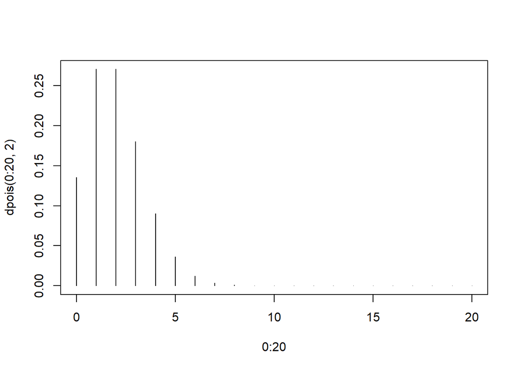

```r
plot(dpois(0:20, 2), type="h", x=0:20)
```

Función de distribución de una Po(2)

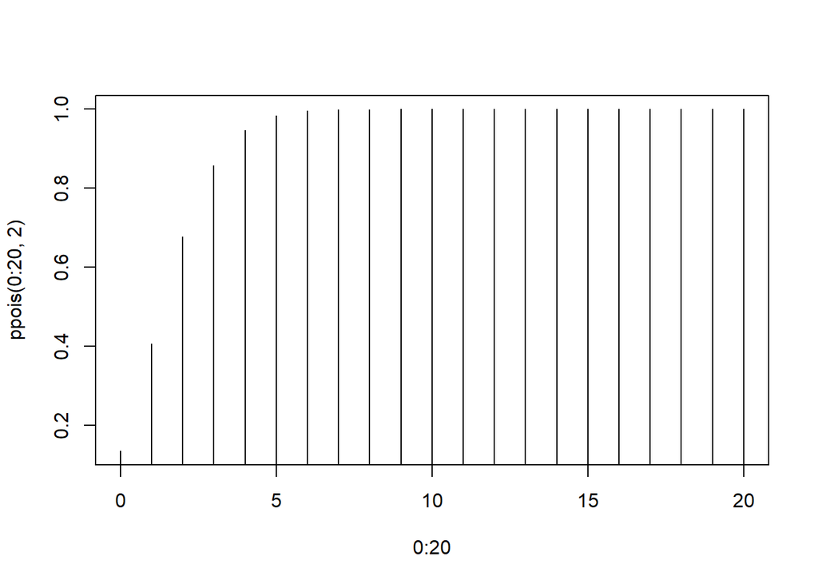

```r
plot(ppois(0:20, 2), type = "h", x=0:20)
```

## Código

- En `R` tenemos las funciones del paquete `stats: dpois(x, lambda), ppois(q, lambda), qpois(p, lambda), rpois(n, lambda)` donde `lambda` es el número esperado de eventos por unidad de tiempo de la distribución.
- En `Python` tenemos las funciones del paquete `scipy.stats.poisson: pmf(k, mu), cdf(k, mu), ppf(q, mu), rvs(M,mu)` donde `mu` es el número esperado de eventos por unidad de tiempo de la distribución.